# Simulated Medical Trial Testing

Preeti Agrawal

2024-12-27

# **Introduction**

```r
# loading the dataset
clinical_data <- read.csv("Simulated_Data_Clinical_Trial.csv")
head(clinical_data)
```

```
##   Patient_ID       Group VAS_Discharge VAS_Admission VAS_Day3 VAS_Day7
## 1          1 Paracetamol      6.996714      9.058633 5.522319 4.627734
## 2          2 Paracetamol      6.361736      8.800526 4.875525 4.126304
## 3          3 Paracetamol      7.147689      9.402393 5.949527 5.406067
## 4          4 Paracetamol      8.023030     10.807765 6.986933 6.218380
## 5          5 Paracetamol      6.265847      8.753887 5.456319 4.662898
## 6          6 Paracetamol      6.265863      8.010265 4.952068 4.079348
##     Satisfaction Side_Effects
## 1      Satisfied     Moderate
## 2 Very Satisfied         Mild
## 3      Satisfied         Mild
## 4        Neutral         Mild
## 5      Satisfied         None
## 6      Satisfied     Moderate
```

```r
# Overview of the dataset
summary(clinical_data)
```

```
##    Patient_ID        Group           VAS_Discharge   VAS_Admission
##  Min.   :  1.00   Length:150         Min.   :3.180   Min.   : 4.817
##  1st Qu.: 38.25   Class :character   1st Qu.:5.328   1st Qu.: 7.576
##  Median : 75.50   Mode  :character   Median :6.050   Median : 8.329
##  Mean   : 75.50                      Mean   :6.018   Mean   : 8.287
##  3rd Qu.:112.75                      3rd Qu.:6.690   3rd Qu.: 8.940
##  Max.   :150.00                      Max.   :8.463   Max.   :11.027
##     VAS_Day3        VAS_Day7     Satisfaction       Side_Effects
##  Min.   :2.284   Min.   :1.488   Length:150         Length:150
##  1st Qu.:4.302   1st Qu.:3.552   Class :character   Class :character
##  Median :5.049   Median :4.312   Mode  :character   Mode  :character
##  Mean   :5.022   Mean   :4.275
##  3rd Qu.:5.681   3rd Qu.:4.938
##  Max.   :7.266   Max.   :6.696
```

```r
glimpse(clinical_data)
```

```
## Rows: 150
## Columns: 8
## $ Patient_ID    <int> 1, 2, 3, 4, 5, 6, 7, 8, 9, 10, 11, 12, 13, 14, 15, 16, 1…
## $ Group         <chr> "Paracetamol", "Paracetamol", "Paracetamol", "Paracetamo…
## $ VAS_Discharge <dbl> 6.996714, 6.361736, 7.147689, 8.023030, 6.265847, 6.2658…
## $ VAS_Admission <dbl> 9.058633, 8.800526, 9.402393, 10.807765, 8.753887, 8.010…
## $ VAS_Day3      <dbl> 5.522319, 4.875525, 5.949527, 6.986933, 5.456319, 4.9520…
## $ VAS_Day7      <dbl> 4.627734, 4.126304, 5.406067, 6.218380, 4.662898, 4.0793…
## $ Satisfaction  <chr> "Satisfied", "Very Satisfied", "Satisfied", "Neutral", "…
## $ Side_Effects  <chr> "Moderate", "Mild", "Mild", "Mild", "None", "Moderate", …
```

```r
# Check for missing values
sum(is.na(clinical_data))
```

```
## [1] 0
```

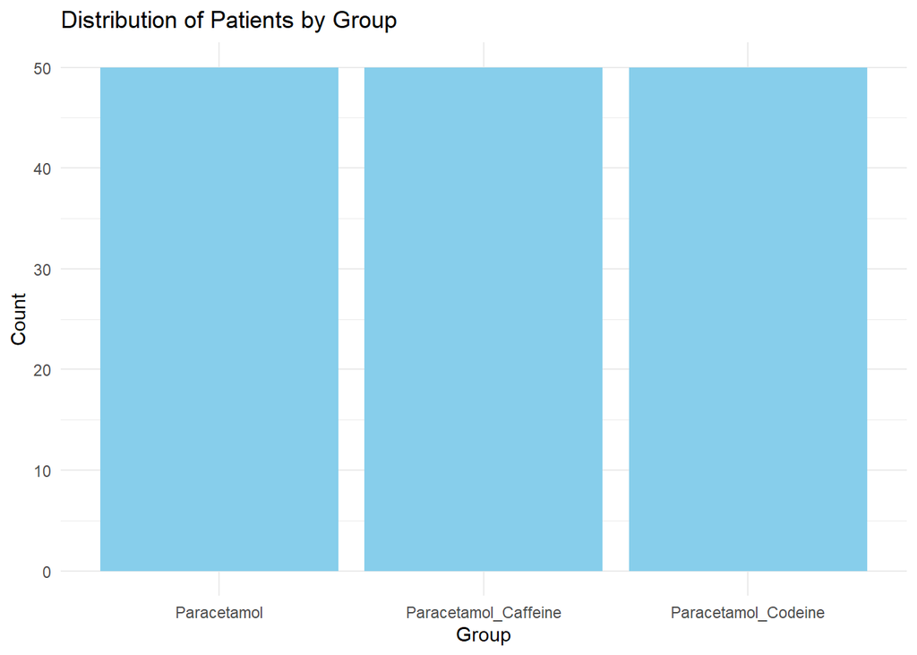

```r
# Distribution of patients across groups
clinical_data %>%
  ggplot(aes(x = Group)) +
  geom_bar(fill = "skyblue") +
  labs(title = "Distribution of Patients by Group", x = "Group", y = "Count") +
  theme_minimal()
```

### Exploring Pain Levels

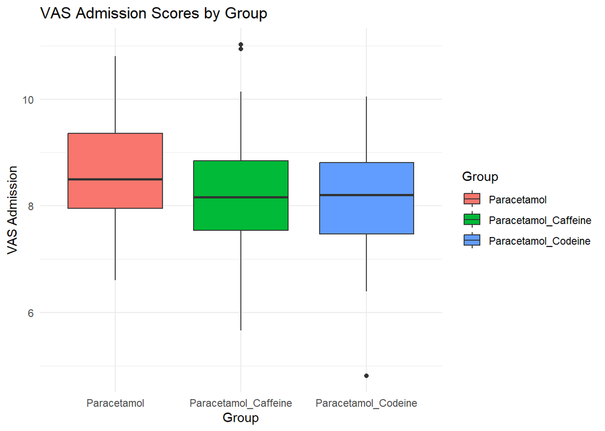

```r
# Boxplot for VAS scores at admission and discharge
clinical_data %>%
  ggplot(aes(x = Group, y = VAS_Admission, fill = Group)) +
  geom_boxplot() +
  labs(title = "VAS Admission Scores by Group", x = "Group", y = "VAS Admission") +
  theme_minimal()
```

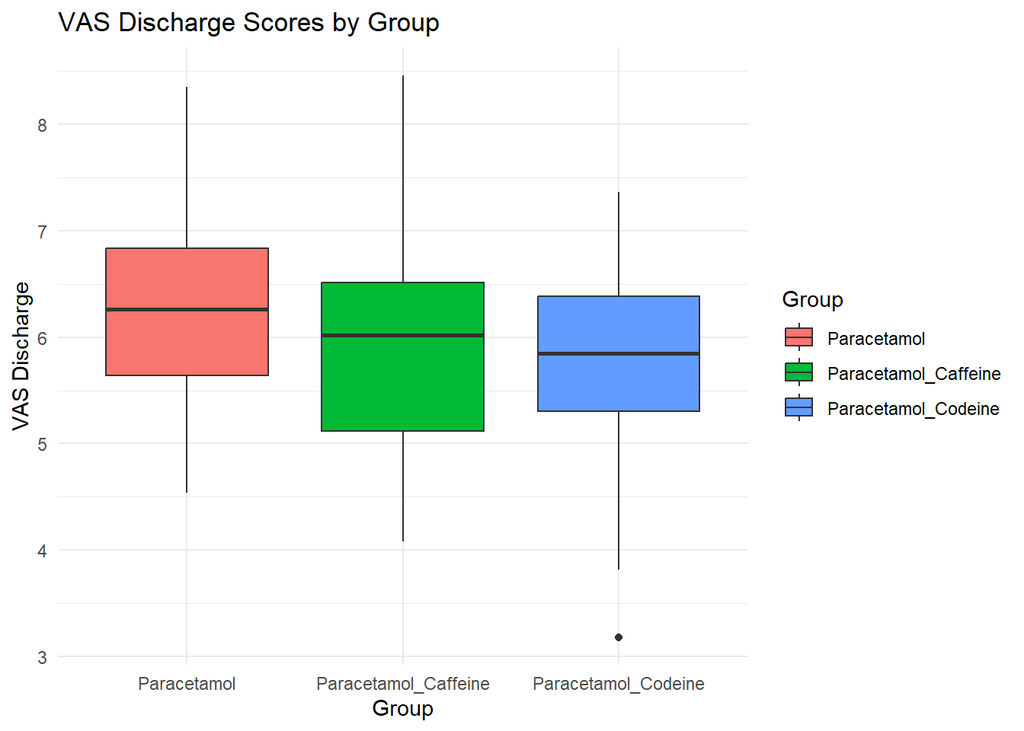

```r
clinical_data %>%
  ggplot(aes(x = Group, y = VAS_Discharge, fill = Group)) +
  geom_boxplot() +
  labs(title = "VAS Discharge Scores by Group", x = "Group", y = "VAS Discharge") +
  theme_minimal()
```

## Methodology

We aim to compare the effectiveness of the three drug groups in reducing pain.

- **Testing Method**: ANOVA (Analysis of Variance) is used to evaluate if there are statistically significant differences in VAS scores among the groups.
  - **Why ANOVA**: Since we are comparing more than two groups, ANOVA is appropriate to test mean differences.

## Analysis

### Checking Assumptions

```r
# Check for normality
shapiro.test(clinical_data$VAS_Discharge[clinical_data$Group == "Paracetamol"])
```

```
##
##  Shapiro-Wilk normality test
##
## data:  clinical_data$VAS_Discharge[clinical_data$Group == "Paracetamol"]
## W = 0.98275, p-value = 0.6722
```

```r
shapiro.test(clinical_data$VAS_Discharge[clinical_data$Group == "Paracetamol_Codeine"])
```

```
##
##  Shapiro-Wilk normality test
##
## data:  clinical_data$VAS_Discharge[clinical_data$Group == "Paracetamol_Codeine"]
## W = 0.97132, p-value = 0.2616
```

```r
shapiro.test(clinical_data$VAS_Discharge[clinical_data$Group == "Paracetamol_Caffeine"])
```

```
##
##  Shapiro-Wilk normality test
##
## data:  clinical_data$VAS_Discharge[clinical_data$Group == "Paracetamol_Caffeine"]
## W = 0.97754, p-value = 0.4534
```

```r
# Check for homogeneity of variances
bartlett.test(VAS_Discharge ~ Group, data = clinical_data)
```

```
##
##  Bartlett test of homogeneity of variances
##
## data:  VAS_Discharge by Group
## Bartlett's K-squared = 1.0967, df = 2, p-value = 0.5779
```

With the assumptions of normality and homogeneity of variances satisfied, an **ANOVA test** is appropriate for comparing the means of the VAS_Discharge variable across the three groups.

### ANOVA Test

```r
# Perform ANOVA
anova_results <- aov(VAS_Discharge ~ Group, data = clinical_data)
summary(anova_results)
```

```
##              Df Sum Sq Mean Sq F value Pr(>F)
## Group         2   5.46  2.7294    3.07 0.0494 *
## Residuals   147 130.70  0.8891
## ---
## Signif. codes:  0 '***' 0.001 '**' 0.01 '*' 0.05 '.' 0.1 ' ' 1
```

```r
# Tukey's HSD post-hoc test
TukeyHSD(anova_results)
```

```
##   Tukey multiple comparisons of means
##     95% family-wise confidence level
##
## Fit: aov(formula = VAS_Discharge ~ Group, data = clinical_data)
##
## $Group
##                                                diff        lwr         upr
## Paracetamol_Caffeine-Paracetamol         -0.3138137 -0.7603187  0.13269140
## Paracetamol_Codeine-Paracetamol          -0.4567452 -0.9032503 -0.01024016
## Paracetamol_Codeine-Paracetamol_Caffeine -0.1429316 -0.5894366  0.30357350
##                                              p adj
## Paracetamol_Caffeine-Paracetamol         0.2225352
## Paracetamol_Codeine-Paracetamol          0.0436986
## Paracetamol_Codeine-Paracetamol_Caffeine 0.7293158
```

### **Key Findings**

- **Paracetamol+Codeine** is significantly more effective in reducing pain (lower VAS_Discharge) compared to **Paracetamol**.
- There is no significant difference in pain relief between **Paracetamol+Caffeine** and the other two groups.

### **Recommendations**

1. Consider **Paracetamol+Codeine** as a potentially more effective treatment for post-traumatic acute pain, particularly when compared to Paracetamol alone.
2. Further studies with larger sample sizes could provide more conclusive evidence, especially for comparisons involving **Paracetamol+Caffeine**.
3. Evaluate side effects and patient satisfaction alongside pain relief to make holistic treatment decisions.